# Epic Cosmos mental health ED visits

`cosmos_mental_health` standardized output

August 03, 2026

**Suppressed cells are excluded from every figure and table below.** 116,510 of 451,200 measure cells (26%) are suppressed.

Some values are negative in Epic Cosmos: 9,513 in min, 4 in avg

# 1. Length of stays

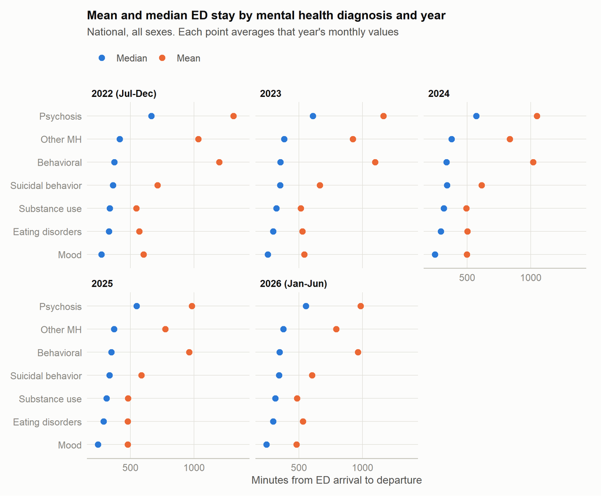

# 2. Trends over time

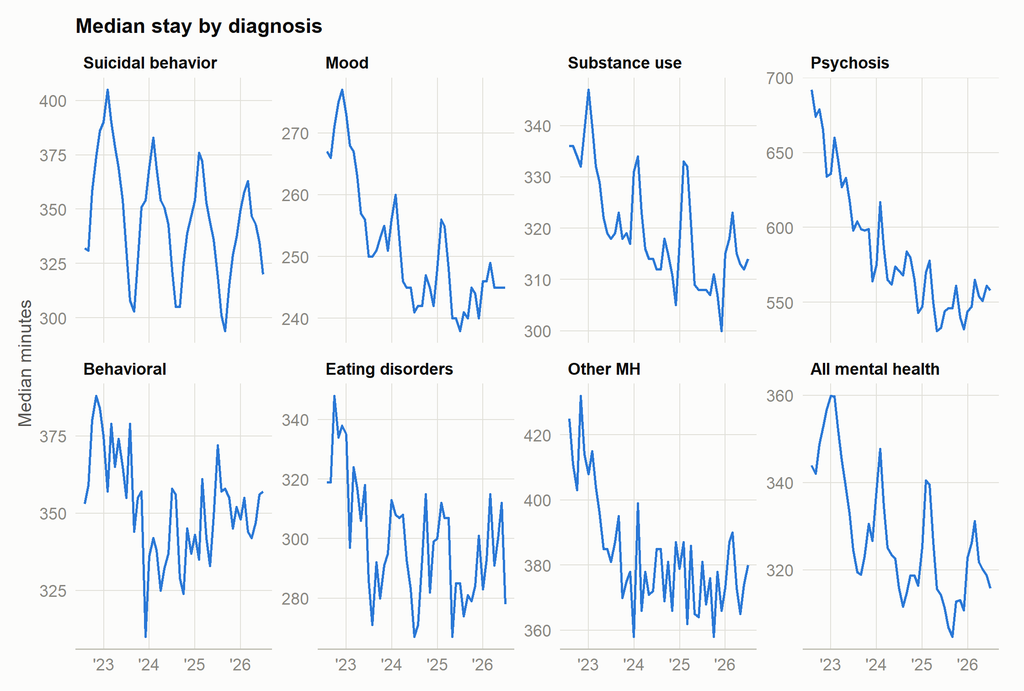

## Stratified by sex

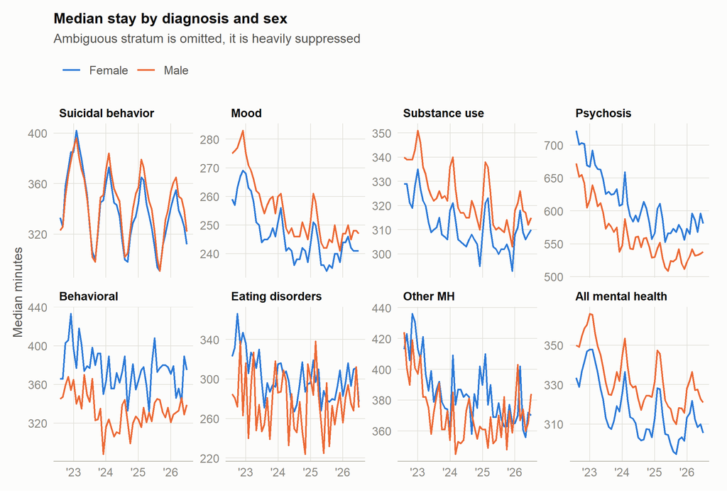

# 3. Median stay by state and diagnosis

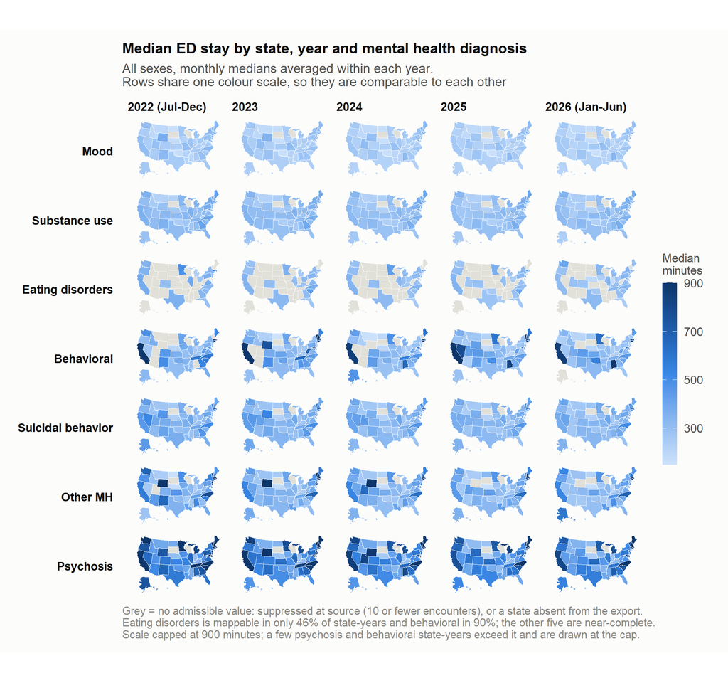

- **The geography is not the same for every diagnosis.** Psychosis and behavioral run long in a different set of states than substance use does, so any single mental health map averages away real variation.
- **Psychosis is both the longest row and the widest**, with far more spread between states than the other diagnoses — it would dominate any combined measure.
- **Eating disorders is mostly grey**, and behavioral is patchy in the sparser states. Those two rows should not be read as geographic patterns; they are closer to a map of where Epic’s footprint is large enough to clear the suppression threshold.

| State | Behavioral | Eating disorders | Mood | Other MH | Psychosis | Substance use | Suicidal behavior |
| --- | --- | --- | --- | --- | --- | --- | --- |
| Alabama | 838 | NA | 323 | 402 | 632 | 308 | 340 |
| Alaska | 289 | NA | 223 | 363 | 523 | 257 | 357 |
| Arizona | 231 | NA | 210 | 264 | 398 | 272 | 273 |
| Arkansas | 291 | NA | 203 | 241 | 317 | 249 | 270 |
| California | 916 | 346 | 258 | 455 | 768 | 308 | 375 |
| Colorado | 454 | 292 | 222 | 380 | 543 | 285 | 344 |
| Connecticut | 1015 | 289 | 384 | 890 | 1029 | 418 | 441 |
| Delaware | 350 | 428 | 272 | 338 | 700 | 379 | 383 |
| District of Columbia | NA | NA | 313 | NA | 690 | 342 | 397 |
| Florida | 262 | 266 | 221 | 328 | 398 | 285 | 282 |
| Georgia | 377 | 289 | 253 | 344 | 590 | 372 | 399 |
| Hawaii | 248 | NA | 192 | 304 | 235 | 254 | 266 |
| Idaho | 250 | NA | 184 | 216 | 308 | 231 | 240 |
| Illinois | 335 | 303 | 254 | 326 | 549 | 334 | 389 |
| Indiana | 235 | NA | 197 | 197 | 285 | 268 | 259 |
| Iowa | 316 | NA | 217 | 279 | 382 | 268 | 301 |
| Kansas | 393 | NA | 248 | 439 | 633 | 308 | 334 |
| Kentucky | 199 | NA | 212 | 269 | 306 | 261 | 252 |
| Louisiana | 321 | 240 | 214 | 445 | 419 | 291 | 315 |
| Maine | 596 | NA | 321 | 539 | 1208 | 403 | 428 |
| Maryland | 615 | NA | 333 | 334 | 717 | 391 | 396 |
| Massachusetts | 796 | 392 | 372 | 812 | 1103 | 398 | 590 |
| Michigan | 306 | 280 | 276 | 398 | 847 | 331 | 357 |
| Minnesota | 606 | 366 | 249 | 475 | 730 | 309 | 349 |
| Mississippi | 294 | NA | 209 | 309 | 381 | 272 | 287 |
| Missouri | 322 | NA | 293 | 311 | 495 | 294 | 337 |
| Montana | 269 | NA | 188 | 244 | 314 | 227 | 255 |
| Nebraska | 185 | NA | 161 | 160 | 228 | 222 | 216 |
| Nevada | 789 | NA | 226 | 263 | 459 | 266 | 376 |
| New Hampshire | 706 | NA | 317 | 980 | 1402 | 348 | 447 |
| New Jersey | 273 | 302 | 284 | 492 | 636 | 360 | 337 |
| New Mexico | 425 | NA | 275 | 356 | 569 | 323 | 354 |
| New York | 290 | 341 | 283 | 372 | 504 | 371 | 334 |
| North Carolina | 429 | 299 | 269 | 638 | 977 | 344 | 467 |
| North Dakota | 220 | NA | 172 | 330 | 287 | 238 | 261 |
| Ohio | 256 | 251 | 240 | 324 | 476 | 312 | 327 |
| Oklahoma | 495 | 248 | 159 | 265 | 375 | 231 | 272 |
| Oregon | 293 | 313 | 221 | 396 | 672 | 283 | 321 |
| Pennsylvania | 273 | 320 | 267 | 404 | 583 | 362 | 376 |
| Rhode Island | 931 | 508 | 579 | 854 | 1596 | 465 | 424 |
| South Carolina | 416 | 407 | 234 | 386 | 732 | 307 | 333 |
| Tennessee | 392 | NA | 218 | 346 | 571 | 305 | 331 |
| Texas | 313 | 283 | 221 | 327 | 532 | 290 | 324 |
| Utah | 428 | 276 | 274 | 433 | 599 | 270 | 364 |
| Vermont | 1084 | NA | 331 | 433 | 806 | 373 | 508 |
| Virginia | 268 | 289 | 230 | 420 | 505 | 300 | 339 |
| Washington | 360 | 277 | 248 | 426 | 729 | 329 | 383 |
| West Virginia | 421 | NA | 230 | 310 | 430 | 326 | 319 |
| Wyoming | 431 | NA | 267 | NA | 654 | 251 | 373 |

The table gives 2025, the most recent complete year, so every mapped value is readable without the colour scale. Blank cells are suppressed.